# CapstoneF3_(1.3)_LALIT_SHARMA

```python
import pandas as pd
```

```python
df=pd.read_csv("C:/car_sales3.csv")
df.head()
```

|  | Sales_ID | name | year | selling_price | km_driven | State or Province | City | fuel | seller_type | transmission | owner | mileage | engine | max_power | seats |
| --- | --- | --- | --- | --- | --- | --- | --- | --- | --- | --- | --- | --- | --- | --- | --- |
| 0 | 1 | Maruti Swift Dzire VDI | 2014 | 450000 | 145500 | District of Columbia | Washington | Diesel | Individual | Manual | First Owner | 23.40 | 1248 | 74.00 | 5 |
| 1 | 2 | Skoda Rapid 1.5 TDI Ambition | 2014 | 370000 | 120000 | New York | New York City | Diesel | Individual | Manual | Second Owner | 21.14 | 1498 | 103.52 | 5 |
| 2 | 3 | Honda City 2017-2020 EXi | 2006 | 158000 | 140000 | Illinois | Chicago | Petrol | Individual | Manual | Third Owner | 17.70 | 1497 | 78.00 | 5 |
| 3 | 4 | Hyundai i20 Sportz Diesel | 2010 | 225000 | 127000 | Illinois | Chicago | Diesel | Individual | Manual | First Owner | 23.00 | 1396 | 90.00 | 5 |
| 4 | 5 | Maruti Swift VXI BSIII | 2007 | 130000 | 120000 | New York | New York City | Petrol | Individual | Manual | First Owner | 16.10 | 1298 | 88.20 | 5 |

```python
df1=pd.read_csv("C:/sales_status.csv")
df1.head()
```

|  | Sales_ID | sold |
| --- | --- | --- |
| 0 | 1 | Y |
| 1 | 2 | Y |
| 2 | 3 | Y |
| 3 | 4 | Y |
| 4 | 5 | Y |

```python
df2=pd.read_csv("C:/region.csv")
df2.head()
```

|  | Region | State or Province |
| --- | --- | --- |
| 0 | Central | Illinois |
| 1 | Central | Indiana |
| 2 | Central | Iowa |
| 3 | Central | Kansas |
| 4 | Central | Michigan |

1.3 a)1) Descriptive statistics for Numerical columns

```python
df.mean()
```

```
Sales_ID           4070.106248
year               2013.983936
selling_price    649813.720845
km_driven         69188.659752
mileage              19.419861
engine             1458.708829
max_power            91.587374
seats                 5.416393
dtype: float64
```

```python
df.median()
```

```
Sales_ID           4076.5
year               2015.0
selling_price    450000.0
km_driven         60000.0
mileage              19.3
engine             1248.0
max_power            82.0
seats                 5.0
dtype: float64
```

```python
df.mode()
```

|  | Sales_ID | name | year | selling_price | km_driven | State or Province | City | fuel | seller_type | transmission | owner | mileage | engine | max_power | seats |
| --- | --- | --- | --- | --- | --- | --- | --- | --- | --- | --- | --- | --- | --- | --- | --- |
| 0 | 1 | Maruti Swift Dzire VDI | 2017.0 | 300000.0 | 120000.0 | California | New York City | Diesel | Individual | Manual | First Owner | 18.9 | 1248.0 | 74.0 | 5.0 |
| 1 | 2 | NaN | NaN | NaN | NaN | NaN | NaN | NaN | NaN | NaN | NaN | NaN | NaN | NaN | NaN |
| 2 | 3 | NaN | NaN | NaN | NaN | NaN | NaN | NaN | NaN | NaN | NaN | NaN | NaN | NaN | NaN |
| 3 | 4 | NaN | NaN | NaN | NaN | NaN | NaN | NaN | NaN | NaN | NaN | NaN | NaN | NaN | NaN |
| 4 | 5 | NaN | NaN | NaN | NaN | NaN | NaN | NaN | NaN | NaN | NaN | NaN | NaN | NaN | NaN |
| ... | ... | ... | ... | ... | ... | ... | ... | ... | ... | ... | ... | ... | ... | ... | ... |
| 7901 | 8124 | NaN | NaN | NaN | NaN | NaN | NaN | NaN | NaN | NaN | NaN | NaN | NaN | NaN | NaN |
| 7902 | 8125 | NaN | NaN | NaN | NaN | NaN | NaN | NaN | NaN | NaN | NaN | NaN | NaN | NaN | NaN |
| 7903 | 8126 | NaN | NaN | NaN | NaN | NaN | NaN | NaN | NaN | NaN | NaN | NaN | NaN | NaN | NaN |
| 7904 | 8127 | NaN | NaN | NaN | NaN | NaN | NaN | NaN | NaN | NaN | NaN | NaN | NaN | NaN | NaN |
| 7905 | 8128 | NaN | NaN | NaN | NaN | NaN | NaN | NaN | NaN | NaN | NaN | NaN | NaN | NaN | NaN |

7906 rows × 15 columns

```python
df['selling_price'].skew()
```

```
4.156863952749261
```

```python
df['selling_price'].kurt()
```

```
20.634384495838116
```

```python
df.describe()
```

|  | Sales_ID | year | selling_price | km_driven | mileage | engine | max_power | seats |
| --- | --- | --- | --- | --- | --- | --- | --- | --- |
| count | 7906.000000 | 7906.000000 | 7.906000e+03 | 7.906000e+03 | 7906.000000 | 7906.000000 | 7906.000000 | 7906.000000 |
| mean | 4070.106248 | 2013.983936 | 6.498137e+05 | 6.918866e+04 | 19.419861 | 1458.708829 | 91.587374 | 5.416393 |
| std | 2345.770159 | 3.863695 | 8.135827e+05 | 5.679230e+04 | 4.036263 | 503.893057 | 35.747216 | 0.959208 |
| min | 1.000000 | 1994.000000 | 2.999900e+04 | 1.000000e+00 | 0.000000 | 624.000000 | 32.800000 | 2.000000 |
| 25% | 2037.250000 | 2012.000000 | 2.700000e+05 | 3.500000e+04 | 16.780000 | 1197.000000 | 68.050000 | 5.000000 |
| 50% | 4076.500000 | 2015.000000 | 4.500000e+05 | 6.000000e+04 | 19.300000 | 1248.000000 | 82.000000 | 5.000000 |
| 75% | 6102.000000 | 2017.000000 | 6.900000e+05 | 9.542500e+04 | 22.320000 | 1582.000000 | 102.000000 | 5.000000 |
| max | 8128.000000 | 2020.000000 | 1.000000e+07 | 2.360457e+06 | 42.000000 | 3604.000000 | 400.000000 | 14.000000 |

1.3 a)2) Descriptive analysis for categorical columns and few insights

```python
df3 = pd.merge(left=df, right=df1,how="outer",on="Sales_ID")
df3.head()
```

|  | Sales_ID | name | year | selling_price | km_driven | State or Province | City | fuel | seller_type | transmission | owner | mileage | engine | max_power | seats | sold |
| --- | --- | --- | --- | --- | --- | --- | --- | --- | --- | --- | --- | --- | --- | --- | --- | --- |
| 0 | 1 | Maruti Swift Dzire VDI | 2014 | 450000 | 145500 | District of Columbia | Washington | Diesel | Individual | Manual | First Owner | 23.40 | 1248 | 74.00 | 5 | Y |
| 1 | 2 | Skoda Rapid 1.5 TDI Ambition | 2014 | 370000 | 120000 | New York | New York City | Diesel | Individual | Manual | Second Owner | 21.14 | 1498 | 103.52 | 5 | Y |
| 2 | 3 | Honda City 2017-2020 EXi | 2006 | 158000 | 140000 | Illinois | Chicago | Petrol | Individual | Manual | Third Owner | 17.70 | 1497 | 78.00 | 5 | Y |
| 3 | 4 | Hyundai i20 Sportz Diesel | 2010 | 225000 | 127000 | Illinois | Chicago | Diesel | Individual | Manual | First Owner | 23.00 | 1396 | 90.00 | 5 | Y |
| 4 | 5 | Maruti Swift VXI BSIII | 2007 | 130000 | 120000 | New York | New York City | Petrol | Individual | Manual | First Owner | 16.10 | 1298 | 88.20 | 5 | Y |

```python
df4 = pd.merge(left=df3, right=df2,how="outer",on="State or Province")
df4.head()
```

|  | Sales_ID | name | year | selling_price | km_driven | State or Province | City | fuel | seller_type | transmission | owner | mileage | engine | max_power | seats | sold | Region |
| --- | --- | --- | --- | --- | --- | --- | --- | --- | --- | --- | --- | --- | --- | --- | --- | --- | --- |
| 0 | 1 | Maruti Swift Dzire VDI | 2014 | 450000 | 145500 | District of Columbia | Washington | Diesel | Individual | Manual | First Owner | 23.40 | 1248 | 74.000 | 5 | Y | East |
| 1 | 38 | Hyundai Verna VTVT 1.6 SX Option | 2019 | 1149000 | 5000 | District of Columbia | Washington | Petrol | Individual | Manual | First Owner | 17.00 | 1591 | 121.300 | 5 | Y | East |
| 2 | 66 | Ford Figo 1.2P Titanium MT | 2017 | 600000 | 25000 | District of Columbia | Washington | Petrol | Individual | Manual | Third Owner | 18.16 | 1196 | 86.800 | 5 | Y | East |
| 3 | 68 | Volkswagen Ameo 1.5 TDI Highline 16 Alloy | 2016 | 540000 | 40000 | District of Columbia | Washington | Diesel | Individual | Manual | First Owner | 22.00 | 1498 | 108.495 | 5 | Y | East |
| 4 | 69 | Honda City i DTEC VX | 2015 | 630000 | 135000 | District of Columbia | Washington | Diesel | Individual | Manual | First Owner | 25.10 | 1498 | 98.600 | 5 | Y | East |

```python
result = df4.loc[df4['sold'] == 'Y']
result.head()
```

|  | Sales_ID | name | year | selling_price | km_driven | State or Province | City | fuel | seller_type | transmission | owner | mileage | engine | max_power | seats | sold | Region |
| --- | --- | --- | --- | --- | --- | --- | --- | --- | --- | --- | --- | --- | --- | --- | --- | --- | --- |
| 0 | 1 | Maruti Swift Dzire VDI | 2014 | 450000 | 145500 | District of Columbia | Washington | Diesel | Individual | Manual | First Owner | 23.40 | 1248 | 74.000 | 5 | Y | East |
| 1 | 38 | Hyundai Verna VTVT 1.6 SX Option | 2019 | 1149000 | 5000 | District of Columbia | Washington | Petrol | Individual | Manual | First Owner | 17.00 | 1591 | 121.300 | 5 | Y | East |
| 2 | 66 | Ford Figo 1.2P Titanium MT | 2017 | 600000 | 25000 | District of Columbia | Washington | Petrol | Individual | Manual | Third Owner | 18.16 | 1196 | 86.800 | 5 | Y | East |
| 3 | 68 | Volkswagen Ameo 1.5 TDI Highline 16 Alloy | 2016 | 540000 | 40000 | District of Columbia | Washington | Diesel | Individual | Manual | First Owner | 22.00 | 1498 | 108.495 | 5 | Y | East |
| 4 | 69 | Honda City i DTEC VX | 2015 | 630000 | 135000 | District of Columbia | Washington | Diesel | Individual | Manual | First Owner | 25.10 | 1498 | 98.600 | 5 | Y | East |

2000 cars out of 7906 cars are sold

```python
import pandas as pd
import numpy as np
import matplotlib.pyplot as plt
import seaborn as sns
sns.set()
from sklearn.cluster import KMeans
```

```python
result['name'].value_counts()
```

```
Maruti Swift Dzire VDI                          42
Maruti Alto 800 LXI                             21
BMW X4 M Sport X xDrive20d                      19
Maruti Wagon R VXI BS IV                        16
Maruti Wagon R LXI                              15
                                                ..
Mahindra Scorpio S11 BSIV                        1
Hyundai Xcent 1.2 Kappa Base                     1
Toyota Glanza V CVT                              1
Toyota Innova 2.5 VX (Diesel) 8 Seater BS IV     1
Maruti Ignis 1.3 Alpha                           1
Name: name, Length: 968, dtype: int64
```

Maruti Swift Dzire VDI cars are sold in highest number

```python
result['City'].value_counts()
```

```
New York City    196
Los Angeles      191
Seattle           86
Chicago           83
Boston            69
                ...
Rutland            1
Shelton            1
Secaucus           1
Fords              1
Portland           1
Name: City, Length: 275, dtype: int64
```

Highest numbers of cars are sold in New York City

```python
result['Region'].value_counts()
```

```
East       630
Central    540
West       487
South      343
Name: Region, dtype: int64
```

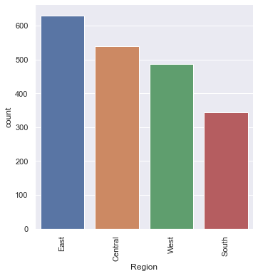

```python
a=sns.catplot(x='Region', data=result,kind="count")
a.set_xticklabels(
    labels=["East","Central","West","South"], rotation=90)
plt.show()
```

Cars in the East region are sold the mos

```python
result['owner'].value_counts()
```

```
First Owner             1326
Second Owner             490
Third Owner              135
Fourth & Above Owner      49
Name: owner, dtype: int64
```

[figure not shown]

```python
a=sns.catplot(x='owner', data=result,kind="count")
a.set_xticklabels(
    labels=["First Owner","Second Owner","Third Owner","Fourth & Above Owner"], rotation=90)
plt.show()
```

Cars owned by First Owner are sold most

```python
result['transmission'].value_counts()
```

```
Manual       1714
Automatic     286
Name: transmission, dtype: int64
```

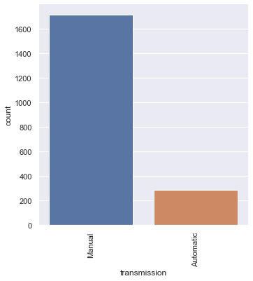

```python
a=sns.catplot(x='transmission', data=result,kind="count")
a.set_xticklabels(
    labels=["Manual","Automatic"], rotation=90)
plt.show()
```

Manual Cars are sold in more number

```python
result['fuel'].value_counts()
```

```
Diesel    1052
Petrol     935
CNG          7
LPG          6
Name: fuel, dtype: int64
```

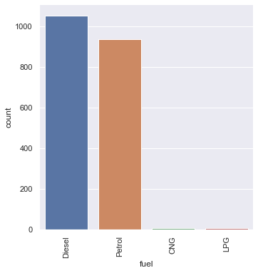

```python
a=sns.catplot(x='fuel', data=result,kind="count")
a.set_xticklabels(
    labels=["Diesel","Petrol","CNG","LPG"], rotation=90)
plt.show()
```

Diesel cars are sold more compared to that of others

```python
result['seller_type'].value_counts()
```

```
Individual          1629
Dealer               291
Trustmark Dealer      80
Name: seller_type, dtype: int64
```

[figure not shown]

```python
a=sns.catplot(x='seller_type', data=result,kind="count")
a.set_xticklabels(
    labels=["Individual","Dealer","Trustmark Dealer"], rotation=90)
plt.show()
```

Cars are bought mostly from individual sellers

```python
result['year'].value_counts()
```

```
2017    256
2016    225
2015    200
2018    187
2013    174
2012    159
2011    155
2019    154
2014    144
2010     96
2009     71
2008     43
2007     28
2005     25
2006     23
2020     19
2004     13
2003     10
2002      7
2000      5
1999      3
2001      2
1994      1
Name: year, dtype: int64
```

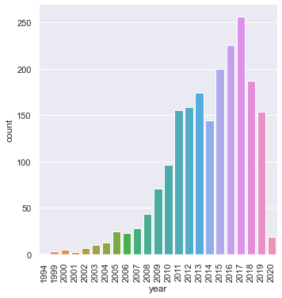

```python
a=sns.catplot(x='year', data=result,kind="count")
a.set_xticklabels(
    labels=['1994', '1999', '2000', '2001', '2002', '2003', '2004', '2005', '2006', '2007', '2008',
       '2009', '2010', '2011', '2012', '2013', '2014', '2015', '2016', '2017', '2018', '2019',
       '2020'], rotation=90)
plt.show()
```

Most sales are made in the year 2017 and there is a decrease in sales from year 2017 to 2020

```python
result['seats'].value_counts()
```

```
5     1568
7      287
8       66
4       34
9       25
6       18
10       2
Name: seats, dtype: int64
```

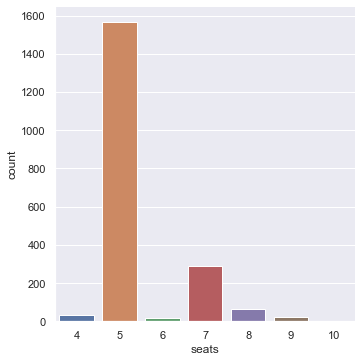

```python
a=sns.catplot(x='seats', data=result,kind="count")
plt.show()
```

Cars that have 5 seats are sold the most

```python
from numpy import mean
```

```python
result.groupby("name").agg({"selling_price":mean}).sort_values("selling_price",ascending=False)
```

| name | selling_price |
| --- | --- |
| Volvo XC90 T8 Excellence BSIV | 1.000000e+07 |
| BMW 6 Series GT 630d Luxury Line | 6.000000e+06 |
| Mercedes-Benz S-Class S 350 CDI | 5.925000e+06 |
| BMW X4 M Sport X xDrive20d | 5.468421e+06 |
| Lexus ES 300h | 5.150000e+06 |
| ... | ... |
| Maruti 800 Std MPFi | 5.500000e+04 |
| Maruti 800 DX | 5.200000e+04 |
| Tata Nano Cx | 4.500000e+04 |
| Maruti 800 DX BSII | 4.500000e+04 |
| Maruti 800 Std BSII | 4.000000e+04 |

968 rows × 1 columns

Volvo XC90 T8 Excellence BSIV is sold at higher price compared to other cars

```python
result["max_power"].mean()
```

```
92.22238000000007
```

```python
result.groupby("fuel").agg({"mileage":mean}).sort_values("mileage",ascending=False)
```

| fuel | mileage |
| --- | --- |
| CNG | 25.314286 |
| LPG | 21.108333 |
| Diesel | 19.366492 |
| Petrol | 18.995936 |

The average mileage for each type of vehicle is determined

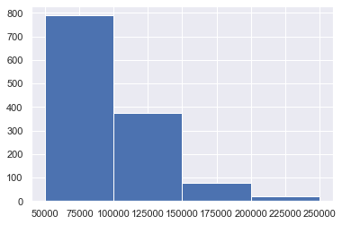

```python
fig,ax=plt.subplots()
ax.hist(result["km_driven"],bins=[50000,100000,150000,200000,250000])
plt.show()
```

The vehicles that are driven upto 100000 kms are sold the most i.e., the more the kms driven the less the number of vehicles sold

# One way ANOVA

```python
df4.head()
```

|  | Sales_ID | name | year | selling_price | km_driven | State or Province | City | fuel | seller_type | transmission | owner | mileage | engine | max_power | seats | sold | Region |
| --- | --- | --- | --- | --- | --- | --- | --- | --- | --- | --- | --- | --- | --- | --- | --- | --- | --- |
| 0 | 1 | Maruti Swift Dzire VDI | 2014 | 450000 | 145500 | District of Columbia | Washington | Diesel | Individual | Manual | First Owner | 23.40 | 1248 | 74.000 | 5 | Y | East |
| 1 | 38 | Hyundai Verna VTVT 1.6 SX Option | 2019 | 1149000 | 5000 | District of Columbia | Washington | Petrol | Individual | Manual | First Owner | 17.00 | 1591 | 121.300 | 5 | Y | East |
| 2 | 66 | Ford Figo 1.2P Titanium MT | 2017 | 600000 | 25000 | District of Columbia | Washington | Petrol | Individual | Manual | Third Owner | 18.16 | 1196 | 86.800 | 5 | Y | East |
| 3 | 68 | Volkswagen Ameo 1.5 TDI Highline 16 Alloy | 2016 | 540000 | 40000 | District of Columbia | Washington | Diesel | Individual | Manual | First Owner | 22.00 | 1498 | 108.495 | 5 | Y | East |
| 4 | 69 | Honda City i DTEC VX | 2015 | 630000 | 135000 | District of Columbia | Washington | Diesel | Individual | Manual | First Owner | 25.10 | 1498 | 98.600 | 5 | Y | East |

```python
import numpy as np
from scipy.stats import f_oneway
```

```python
Petrol=df4[df4["fuel"]=="Petrol"]["selling_price"]
Diesel=df4[df4["fuel"]=="Diesel"]["selling_price"]
LPG=df4[df4["fuel"]=="LPG"]["selling_price"]
CNG=df4[df4["fuel"]=="CNG"]["selling_price"]
```

Ho:The type of fuel does not effect the seeling price of car

H1:The type of fuel does effect the selling price of car

```python
f_oneway(Petrol,Diesel,LPG,CNG)
```

```
F_onewayResult(statistic=117.30554435257855, pvalue=2.52340474514499e-74)
```

CONCLUSION:As the p value is less than 0.05 we reject the null hypothesis

Therefore the type of fuel does effect the selling price of car

# Two way ANOVA testing

1) Relationship between column of interest i.e., selling_price and first categorical column i.e., owner

Ho:The type of owner does not affect the selling_price

H1:The type of owner does affect the seling_price

2) Relationship between column of interest i.e., selling_price and first categorical column i.e., seller_type

Ho:The seller_type does not affect the selling_price

H1:The seller_type does affect the selling_price

3) Relationship between column of interest i.e., selling_price and both the categorical columns i.e., owner and seller_type

Ho:The owner and seller_type does not affect the selling_price

H1:The owner and seller_type does affect the selling_price

```python
from statsmodels.formula.api import ols
```

```python
two_way=ols('selling_price~C(owner)+C(seller_type)+C(owner):C(seller_type)',data=df4).fit()
import statsmodels.api as sm
sm.stats.anova_lm(two_way)
```

|  | df | sum_sq | mean_sq | F | PR(>F) |
| --- | --- | --- | --- | --- | --- |
| C(owner) | 4.0 | 3.901560e+14 | 9.753900e+13 | 185.369823 | 4.353160e-152 |
| C(seller_type) | 2.0 | 6.523541e+14 | 3.261770e+14 | 619.889227 | 8.708024e-251 |
| C(owner):C(seller_type) | 8.0 | 3.980004e+13 | 4.975006e+12 | 9.454842 | 4.280838e-13 |
| Residual | 7896.0 | 4.154765e+15 | 5.261860e+11 | NaN | NaN |

CONCLUSION: According to the two way anova hypothesis testing performed

1) p value for C(owner)<0.05 so we reject null hypothesis, therefore the type of owner does effect the selling price of car

2) p value for C(seller_type)<0.05 so we reject null hypothesis, therefore the seller type does effect the selling price of car

3) p value for C(owner):C(seller_type)<0.05 so reject null hypothesis,therefore the type of owner and the seller type does effect the selling price of car

# t test

Problem Statement: Cars association claims that the average selling price is 600000. But the government does not believe so. That is why, the government collected selling price data of 30 cars

Ho:Average selling price of cars is 600000

H1:Average selling price of cars is not 600000

```python
from scipy.stats import ttest_1samp
```

```python
samples=df4.iloc[0:30,:]["selling_price"].values
tscore,pvalue=ttest_1samp(a=samples,popmean=600000,alternative="two-sided")
pvalue
```

```
0.6426754555531551
```

CONCLUSION: As the p value is greater than 0.05 we fail to reject the null hypothesis

# chi square test

Ho: There is no relation between the City and fuel of car

H1: There is a relation between City and fuel of car

```python
from scipy.stats import chi2_contingency
data=pd.crosstab(df4["City"],df4["fuel"])
data
```

| fuel City | CNG | Diesel | LPG | Petrol |
| --- | --- | --- | --- | --- |
| Abilene | 0 | 3 | 0 | 4 |
| Abington | 0 | 1 | 0 | 0 |
| Acton | 0 | 0 | 0 | 1 |
| Addison | 0 | 0 | 0 | 1 |
| Adrian | 0 | 4 | 0 | 1 |
| ... | ... | ... | ... | ... |
| York | 0 | 4 | 0 | 1 |
| Youngstown | 0 | 2 | 0 | 1 |
| Yuba City | 0 | 2 | 0 | 0 |
| Yucaipa | 0 | 2 | 0 | 0 |
| Yuma | 0 | 0 | 0 | 5 |

1310 rows × 4 columns

```python
tabular,PValue,Df,Calculated=chi2_contingency(data)
PValue
```

```
3.0777515443858005e-23
```

CONCLUSION: As the p value is less than 0.05 we reject the null hypothesis

Ho: There is no relation between the Seller_type and owner

H1: There is a relation between Seller_type and owner

```python
data1=pd.crosstab(df4["seller_type"],df4["owner"])
tabular,PValue,Df,Calculated=chi2_contingency(data1)
data1
```

| owner seller_type | First Owner | Fourth & Above Owner | Second Owner | Test Drive Car | Third Owner |
| --- | --- | --- | --- | --- | --- |
| Dealer | 1006 | 0 | 92 | 5 | 4 |
| Individual | 4006 | 160 | 1891 | 0 | 506 |
| Trustmark Dealer | 203 | 0 | 33 | 0 | 0 |

```python
PValue
```

```
2.001346722330203e-96
```

CONCLUSION : As the P value is less than 0.05 we reject the null hypothesis

Ho: There is no relation between the transmission and owner

H1: There is a relation between transmission and owner

```python
data2=pd.crosstab(df4["transmission"],df4["owner"])
tabular,PValue,Df,Calculated=chi2_contingency(data1)
data2
```

| owner transmission | First Owner | Fourth & Above Owner | Second Owner | Test Drive Car | Third Owner |
| --- | --- | --- | --- | --- | --- |
| Automatic | 888 | 6 | 123 | 4 | 20 |
| Manual | 4327 | 154 | 1893 | 1 | 490 |

```python
PValue
```

```
2.001346722330203e-96
```